[figure not shown]

# Fraud Detection and Insights Using Machine Learning

Collaborators: Sivram Sahu, Akshay Kamkhalia

1. Introduction and Motivation
2. Data explanation
3. Data cleaning and processing
4. Exploratory Data Analysis
5. Models, algorithms ,and training
6. Interpretation of Results
7. Conclusion
8. References

## Introduction

Online financial payments have transformed the way people manage their money, offering convenience, speed, and accessibility like never before. However, this rise in digital transactions has also led to an increase in fraudulent activities, posing serious risks to individuals, businesses, and financial institutions. Fraud detection for online financial payments plays a vital role in addressing these challenges by ensuring the safety and security of digital financial systems.

## Motivation

One of the main reasons for choosing this topic is the rapid adoption of digital payment methods, such as mobile wallets, online banking, and cryptocurrencies. With the growing number of users, fraudsters have developed more advanced techniques, making it increasingly difficult for traditional methods to detect and prevent fraud effectively. This calls for innovative approaches to stay ahead of these threats. The alarming rise in payment fraud incidents highlights the critical need for robust fraud detection mechanisms. In 2023 alone, consumers globally lost a staggering $10 billion to fraud, marking a 14% increase from the previous year. This trend underscores the urgent necessity for financial institutions and businesses to implement advanced fraud detection solutions to protect their customers and themselves from financial losses and reputational damage.

Another motivation is the financial and reputational damage caused by fraud. Fraud not only results in monetary losses but also erodes trust in online platforms and creates significant challenges for businesses trying to recover. Developing effective fraud detection systems can help protect users and businesses while fostering confidence in digital payment systems.

Additionally, this topic allows the exploration of cutting-edge technologies like machine learning, blockchain, and advanced data analysis to build better fraud detection systems. These technologies can improve accuracy, protect user privacy, and comply with important regulations, ensuring secure and trustworthy financial transactions.

Finally, studying fraud detection provides valuable insights into fraudulent behavior and system vulnerabilities. This knowledge can help create adaptable systems that respond effectively to emerging threats, enhancing the overall security of online payments.

## Important

1. Each row represents a Single Transaction
2. Ignore the warning messages in a few code cells

## Important Libraries and Modules

This project utilizes various Libraries and Modules majority of them have been listed and imported below, with a few uncommon modules such as lighbgm being installed on the go, and some of the libraries that are specific to some problems have been installed later along with the code

```python
!pip install lightgbm
!pip install catboost
!pip install shap
import pandas as pd
import seaborn as sns
import matplotlib.pyplot as plt
from sklearn.preprocessing import StandardScaler
from sklearn.linear_model import LogisticRegression
from sklearn.model_selection import train_test_split
from sklearn.metrics import classification_report, roc_auc_score
from sklearn.preprocessing import OneHotEncoder
from sklearn.compose import ColumnTransformer
from sklearn.pipeline import Pipeline
from imblearn.over_sampling import SMOTE
```

## Data Explanation

This is an Online payment fraud dataset with total rows = **6362620** and total columns= **16**. column description

- **step**: Represents a unit of time where 1 step equals 1 hour.
- **type**: Type of online transaction.
- **amount**: The amount of the transaction.
- **nameOrig**: Customer starting the transaction.
- **oldbalanceOrg**: Balance before the transaction.
- **newbalanceOrig**: Balance after the transaction.
- **nameDest**: Recipient of the transaction.
- **oldbalanceDest**: Initial balance of recipient before the transaction.
- **newbalanceDest**: The new balance of the recipient after the transaction.
- **isFraud**: Indicates whether the transaction is fraudulent.
- **isFlaggedFraud**: Indicates whether the transaction is marked as Fraud by the existing system.
- **State**: The U.S. state where the transaction originated.
- **merchant_category**: The category of the merchant to which the payment was made.
- **time_of_day**: Specifies whether the transaction occurred in the morning, afternoon, evening, or night.
- **Currency**: All transactions are in USD.
- **time**: Timestamp of the transaction.

**Important**

1. This is a Highly imbalanced, unclean dataset replicating real-life scenarios during Fraud detection at Financial Companies. The imbalance is of about less than 1%, indicating less than 1% data representing Fraudulent Transaction
2. With the help of States, Time, Merchant category, etc, we can find out a lot about the current trends in Fraud across various segments

```python
file_path = "Fraud Dataset.csv"
data = pd.read_csv(file_path)
```

```python
data.head()
```

|  | step | type | amount | nameOrig | oldbalanceOrg | newbalanceOrig | nameDest | oldbalanceDest | newbalanceDest | isFraud | isFlaggedFraud | State | merchant_category | time_of_day | Currency | time |
| --- | --- | --- | --- | --- | --- | --- | --- | --- | --- | --- | --- | --- | --- | --- | --- | --- |
| 0 | NaN | PAYMENT | 9839.64 | C1231006815 | 170136.0 | 160296.36 | M1979787155 | 0.0 | 0.0 | 0 | 0.0 | Alaska | Groceries | Evening | USD | 20:09:09 |
| 1 | 1.0 | PAYMENT | 1864.28 | C1666544295 | NaN | 19384.72 | M2044282225 | 0.0 | 0.0 | 0 | 0.0 | Kentucky | Housing | Night | USD | NaN |
| 2 | 1.0 | TRANSFER | 181.00 | C1305486145 | 181.0 | 0.00 | C553264065 | 0.0 | 0.0 | 1 | 0.0 | Washington | Housing | Night | USD | 22:38:16 |
| 3 | 1.0 | CASH_OUT | 181.00 | C840083671 | 181.0 | 0.00 | C38997010 | 21182.0 | 0.0 | 1 | 0.0 | Maryland | Groceries | Night | USD | 23:31:48 |
| 4 | NaN | PAYMENT | 11668.14 | C2048537720 | 41554.0 | 29885.86 | NaN | 0.0 | 0.0 | 0 | 0.0 | Indiana | NaN | Evening | USD | 21:00:45 |

All the datatypes are assigned correctly upon initial inspection

```python
data.info()
```

```
<class 'pandas.core.frame.DataFrame'>
RangeIndex: 6362620 entries, 0 to 6362619
Data columns (total 16 columns):
 #   Column             Dtype
---  ------             -----
 0   step               float64
 1   type               object
 2   amount             float64
 3   nameOrig           object
 4   oldbalanceOrg      float64
 5   newbalanceOrig     float64
 6   nameDest           object
 7   oldbalanceDest     float64
 8   newbalanceDest     float64
 9   isFraud            int64
 10  isFlaggedFraud     float64
 11  State              object
 12  merchant_category  object
 13  time_of_day        object
 14  Currency           object
 15  time               object
dtypes: float64(7), int64(1), object(8)
memory usage: 776.7+ MB
```

### Null Values

We do have about 600k missing values for each column except the isFraud Column which makes it about 10% null values with respect to each column. While we do have a huge amount of data already, deleting these values seems a good idea, but we need to investigate further whether or not we can directly delete or we can impute some values

```python
print("Missing Values Summary:")
data.isnull().sum()
```

```
Missing Values Summary:
```

```
step                 636931
type                 636971
amount               635503
nameOrig             635400
oldbalanceOrg        636465
newbalanceOrig       636671
nameDest             634600
oldbalanceDest       636399
newbalanceDest       635336
isFraud                   0
isFlaggedFraud       634204
State                635548
merchant_category    635844
time_of_day          634790
Currency             635379
time                 634874
dtype: int64
```

There are No Duplicate rows recorded

```python
#Check for duplicate rows
duplicates = data.duplicated().sum()
print(f"Number of duplicate rows: {duplicates}")
print("\n")
```

```
Number of duplicate rows: 0
```

This gives an overview of Descriptive Statistics within the Numerical columns, showcasing mean, count, std, min, max, and quartiles for each column, which can be used for further analysis for example, what is the mean amount of txn in USD across the entire dataset?? or what is the STD for a particular column??

```python
#Check basic statistics of numerical columns
data.describe()
```

```
Descriptive Statistics:
```

|  | step | amount | oldbalanceOrg | newbalanceOrig | oldbalanceDest | newbalanceDest | isFraud | isFlaggedFraud |
| --- | --- | --- | --- | --- | --- | --- | --- | --- |
| count | 5.725689e+06 | 5.727117e+06 | 5.726155e+06 | 5.725949e+06 | 5.726221e+06 | 5.727284e+06 | 6.362620e+06 | 5.728416e+06 |
| mean | 2.434369e+02 | 1.801073e+05 | 8.338695e+05 | 8.553543e+05 | 1.101267e+06 | 1.224922e+06 | 1.290820e-03 | 2.793093e-06 |
| std | 1.423789e+02 | 6.044018e+05 | 2.888457e+06 | 2.924352e+06 | 3.406300e+06 | 3.676676e+06 | 3.590480e-02 | 1.671253e-03 |
| min | 1.000000e+00 | 0.000000e+00 | 0.000000e+00 | 0.000000e+00 | 0.000000e+00 | 0.000000e+00 | 0.000000e+00 | 0.000000e+00 |
| 25% | 1.560000e+02 | 1.338853e+04 | 0.000000e+00 | 0.000000e+00 | 0.000000e+00 | 0.000000e+00 | 0.000000e+00 | 0.000000e+00 |
| 50% | 2.390000e+02 | 7.491213e+04 | 1.422300e+04 | 0.000000e+00 | 1.327682e+05 | 2.146901e+05 | 0.000000e+00 | 0.000000e+00 |
| 75% | 3.350000e+02 | 2.087943e+05 | 1.073840e+05 | 1.442456e+05 | 9.434232e+05 | 1.112120e+06 | 0.000000e+00 | 0.000000e+00 |
| max | 7.430000e+02 | 9.244552e+07 | 5.958504e+07 | 4.958504e+07 | 3.560159e+08 | 3.561793e+08 | 1.000000e+00 | 1.000000e+00 |

```python
## Data Explantion
```

```python
#Summary of unique values in each column
print("Unique Values in Each Column:")
for column in data.columns:
    print(f"{column}: {data[column].nunique()} unique values")
```

```
Unique Values in Each Column:
step: 743 unique values
type: 5 unique values
amount: 4856525 unique values
nameOrig: 5719701 unique values
oldbalanceOrg: 1680912 unique values
newbalanceOrig: 2419939 unique values
nameDest: 2495936 unique values
oldbalanceDest: 3256605 unique values
newbalanceDest: 3226084 unique values
isFraud: 2 unique values
isFlaggedFraud: 2 unique values
State: 50 unique values
merchant_category: 8 unique values
time_of_day: 4 unique values
Currency: 1 unique values
time: 82742 unique values
```

```python
# Critical columns: 'step', 'type', 'amount', 'isFraud'
data_cleaned = data.dropna(subset=['step', 'type', 'amount', 'isFraud']).copy()

# Impute missing numerical values with the median
numerical_columns = ['oldbalanceOrg', 'newbalanceOrig', 'oldbalanceDest', 'newbalanceDest']
for col in numerical_columns:
    data_cleaned.loc[:, col] = data_cleaned[col].fillna(data_cleaned[col].median())

#Impute missing categorical values with the mode
categorical_columns = ['State', 'merchant_category', 'time_of_day']
for col in categorical_columns:
    if col in data_cleaned.columns:  # Ensure the column exists in the dataset
        data_cleaned.loc[:, col] = data_cleaned[col].fillna(data_cleaned[col].mode()[0])

# Drop low-variance or irrelevant columns
irrelevant_columns = ['Currency', 'nameOrig', 'nameDest', 'time']
data_cleaned = data_cleaned.drop(columns=irrelevant_columns, errors='ignore')

#Reset index after cleaning
data_cleaned = data_cleaned.reset_index(drop=True)

#Output cleaned dataset summary
print("Cleaned Dataset Summary:")
print(data_cleaned.info())
print("\nMissing Values after Cleaning:")
print(data_cleaned.isnull().sum())
print("\nFirst few rows of the cleaned dataset:")
print(data_cleaned.head())
```

```
Cleaned Dataset Summary:
<class 'pandas.core.frame.DataFrame'>
RangeIndex: 4637838 entries, 0 to 4637837
Data columns (total 12 columns):
 #   Column             Dtype
---  ------             -----
 0   step               float64
 1   type               object
 2   amount             float64
 3   oldbalanceOrg      float64
 4   newbalanceOrig     float64
 5   oldbalanceDest     float64
 6   newbalanceDest     float64
 7   isFraud            int64
 8   isFlaggedFraud     float64
 9   State              object
 10  merchant_category  object
 11  time_of_day        object
dtypes: float64(7), int64(1), object(4)
memory usage: 424.6+ MB
None

Missing Values after Cleaning:
step                      0
type                      0
amount                    0
oldbalanceOrg             0
newbalanceOrig            0
oldbalanceDest            0
newbalanceDest            0
isFraud                   0
isFlaggedFraud       462132
State                     0
merchant_category         0
time_of_day               0
dtype: int64

First few rows of the cleaned dataset:
   step      type   amount  oldbalanceOrg  newbalanceOrig  oldbalanceDest  \
0   1.0   PAYMENT  1864.28       14267.73        19384.72             0.0
1   1.0  TRANSFER   181.00         181.00            0.00             0.0
2   1.0  CASH_OUT   181.00         181.00            0.00         21182.0
3   1.0   PAYMENT  7817.71       53860.00        46042.29             0.0
4   1.0   PAYMENT  7107.77      183195.00       176087.23             0.0

   newbalanceDest  isFraud  isFlaggedFraud          State merchant_category  \
0             0.0        0             0.0       Kentucky           Housing
1             0.0        1             0.0     Washington           Housing
2             0.0        1             0.0       Maryland         Groceries
3             0.0        0             0.0  Massachusetts     Entertainment
4             0.0        0             0.0        Wyoming         Groceries

  time_of_day
0       Night
1       Night
2       Night
3     Evening
4     Evening
```

## Data Cleaning and Preprocessing

#### **Missing Data**

- After careful analysis, we decide to drop the Null values with respect to columns 'step', 'type', 'amount', 'isFraud'.
- For columns 'oldbalanceOrg', 'newbalanceOrig', 'oldbalanceDest', and 'newbalanceDest', as they are numerical, we impute the missing values with the median of those columns.
- For Columns 'State', 'merchant_category', and 'time_of_day', as they have Strings or categorical values, we impute them using Mode
- **Thus, Missing Data is taken care off**

#### **Irrelevant Columns**

- Columns such as 'Currency', 'nameOrig', 'nameDest', and 'time' have been deleted because Currency is USD across every row, and time is not relevant because we already have another column stating whether it was morning, evening, afternoon or night hence duplicated data is not necessary
- **Dropped all the Irrelevant Columns**
- **Further preprocessing Like encoding and handling imbalance, Feature Engineering can be seen before model Building**

```python
# Impute missing values in 'isFlaggedFraud' with 0 (non-flagged assumption)
data_cleaned['isFlaggedFraud'] = data_cleaned['isFlaggedFraud'].fillna(0)

# Verify if all missing values are handled
print("Missing Values after Handling 'isFlaggedFraud':")
print(data_cleaned.isnull().sum())
```

```
Missing Values after Handling 'isFlaggedFraud':
step                 0
type                 0
amount               0
oldbalanceOrg        0
newbalanceOrig       0
oldbalanceDest       0
newbalanceDest       0
isFraud              0
isFlaggedFraud       0
State                0
merchant_category    0
time_of_day          0
dtype: int64
```

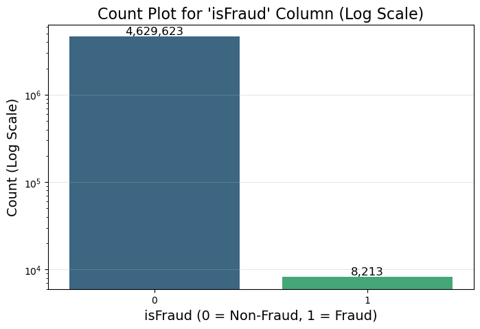

```python
# Create a count plot for the 'isFraud' column
plt.figure(figsize=(8, 5))
sns.countplot(x='isFraud', data=data_cleaned, palette="viridis")

# Use a logarithmic scale for the y-axis
plt.yscale('log')

# Annotate the bars with counts
for index, value in enumerate(data_cleaned['isFraud'].value_counts()):
    plt.text(index, value, f'{value:,}', ha='center', va='bottom', fontsize=12)

# Add labels and title
plt.title("Count Plot for 'isFraud' Column (Log Scale)", fontsize=16)
plt.xlabel("isFraud (0 = Non-Fraud, 1 = Fraud)", fontsize=14)
plt.ylabel("Count (Log Scale)", fontsize=14)
plt.grid(axis='y', alpha=0.3)
plt.show()
```

## Exploratory Data Analysis

**Count Plot** for the target variable isFraud

-**Class Imbalance**: The graph shows the distribution of non-fraud (isFraud = 0) and fraud (isFraud = 1) transactions. A large difference between the heights of the bars indicates a highly imbalanced dataset, which is typical in fraud detection scenarios.

-**Logarithmic Scale**: The y-axis uses a logarithmic scale to make the smaller fraud counts (isFraud = 1) visible while maintaining the proportional difference compared to non-fraud transactions.

-**Fraud Prevalence**: The graph visually emphasizes how rare fraudulent transactions are compared to non-fraudulent ones, which helps highlight the challenge of detecting fraud in such datasets.

```python
data_cleaned
```

|  | step | type | amount | oldbalanceOrg | newbalanceOrig | oldbalanceDest | newbalanceDest | isFraud | isFlaggedFraud | State | merchant_category | time_of_day |
| --- | --- | --- | --- | --- | --- | --- | --- | --- | --- | --- | --- | --- |
| 0 | 1.0 | PAYMENT | 1864.28 | 14267.73 | 19384.72 | 0.00 | 0.00 | 0 | 0.0 | Kentucky | Housing | Night |
| 1 | 1.0 | TRANSFER | 181.00 | 181.00 | 0.00 | 0.00 | 0.00 | 1 | 0.0 | Washington | Housing | Night |
| 2 | 1.0 | CASH_OUT | 181.00 | 181.00 | 0.00 | 21182.00 | 0.00 | 1 | 0.0 | Maryland | Groceries | Night |
| 3 | 1.0 | PAYMENT | 7817.71 | 53860.00 | 46042.29 | 0.00 | 0.00 | 0 | 0.0 | Massachusetts | Entertainment | Evening |
| 4 | 1.0 | PAYMENT | 7107.77 | 183195.00 | 176087.23 | 0.00 | 0.00 | 0 | 0.0 | Wyoming | Groceries | Evening |
| ... | ... | ... | ... | ... | ... | ... | ... | ... | ... | ... | ... | ... |
| 4637833 | 743.0 | CASH_OUT | 339682.13 | 339682.13 | 0.00 | 0.00 | 339682.13 | 1 | 0.0 | Illinois | Groceries | Afternoon |
| 4637834 | 743.0 | TRANSFER | 6311409.28 | 6311409.28 | 0.00 | 0.00 | 0.00 | 1 | 0.0 | New Jersey | Entertainment | Afternoon |
| 4637835 | 743.0 | CASH_OUT | 6311409.28 | 6311409.28 | 0.00 | 68488.84 | 6379898.11 | 1 | 0.0 | Tennessee | Entertainment | Night |
| 4637836 | 743.0 | TRANSFER | 850002.52 | 850002.52 | 0.00 | 0.00 | 0.00 | 1 | 0.0 | North Carolina | Housing | Evening |
| 4637837 | 743.0 | CASH_OUT | 850002.52 | 850002.52 | 0.00 | 6510099.11 | 7360101.63 | 1 | 0.0 | Maryland | Entertainment | Night |

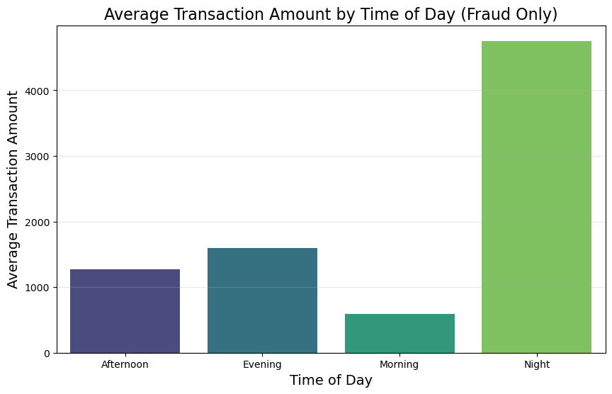

```python
# Filter the data for fraud transactions only
fraud_data = data_cleaned[data_cleaned['isFraud'] == 1]

# Calculate the average transaction amount grouped by 'time_of_day'
average_txn_fraud = fraud_data.groupby(['time_of_day'])['amount'].count().reset_index()

# Create the bar plot
plt.figure(figsize=(10, 6))
sns.barplot(
    x='time_of_day',
    y='amount',
    data=average_txn_fraud,
    palette='viridis'
)

# Add labels and title
plt.title("Average Transaction Amount by Time of Day (Fraud Only)", fontsize=16)
plt.xlabel("Time of Day", fontsize=14)
plt.ylabel("Average Transaction Amount", fontsize=14)
plt.grid(axis='y', alpha=0.3)
plt.show()
```

**Risk Assessment**: Understanding the time-of-day patterns can help assess when transactions are riskier, allowing businesses to strengthen fraud detection measures during high-risk periods.

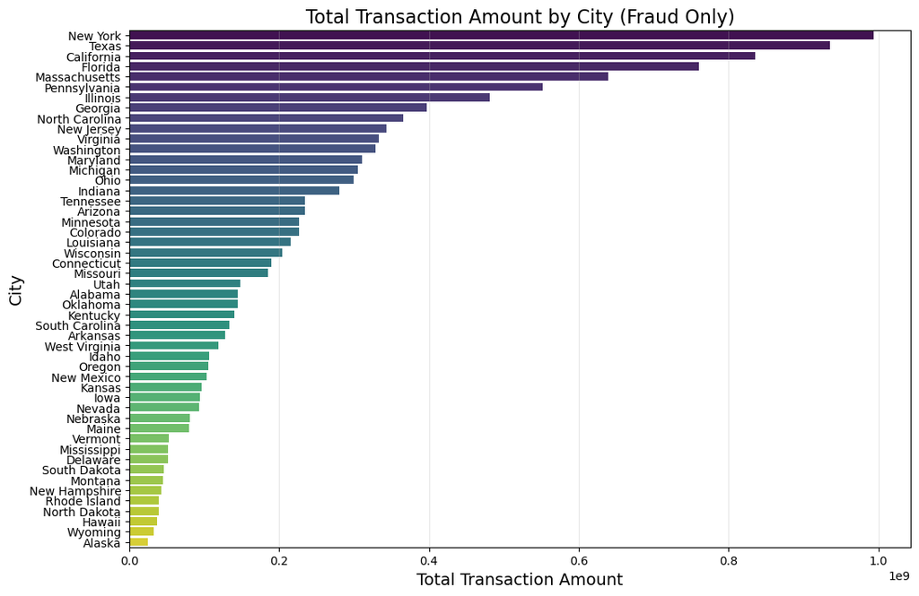

```python
# Group the data for fraud transactions by city and calculate the total transaction amount
fraud_city_totals = data_cleaned[data_cleaned['isFraud'] == 1].groupby('State')['amount'].sum().reset_index()

# Sort by total transaction amount in descending order
fraud_city_totals = fraud_city_totals.sort_values(by='amount', ascending=False)

# Create the bar plot
plt.figure(figsize=(12, 8))
sns.barplot(
    y='State',
    x='amount',
    data=fraud_city_totals,
    palette='viridis'
)

# Add labels and title
plt.title("Total Transaction Amount by City (Fraud Only)", fontsize=16)
plt.xlabel("Total Transaction Amount", fontsize=14)
plt.ylabel("City", fontsize=14)
plt.grid(axis='x', alpha=0.3)
plt.show()
```

### Sum of Transactions that are Fraud segrated with respect to States in the USA

- **Total Fraudulent Transaction Amount by State**:
  - The graph displays the **total monetary value** of fraudulent transactions (`isFraud = 1`) for each state.
  - States are represented along the y-axis, while the x-axis shows the total transaction amount.
- **Sorting by Total Amount**:
  - The states are sorted in **descending order** of the total fraudulent transaction amount.
  - This ensures that the states with the **highest fraud-related monetary losses** are displayed at the top.

## Insights

- **High-Risk States**:
  - States like **New York**, **Texas**, **California**, and **Florida** dominate the total fraudulent transaction amounts. These states experience significantly higher financial losses due to fraud, suggesting they are hotspots for fraudulent activity.
- **Moderate-Risk States**:
  - States such as **Massachusetts**, **Pennsylvania**, **Illinois**, and **Georgia** show considerable fraudulent transaction amounts but are less affected than the top-tier states.
- **Low-Risk States**:
  - States like **Wyoming**, **Alaska**, and **Hawaii** exhibit the least amount of fraudulent transaction activity. These states face minimal financial impact due to fraud.

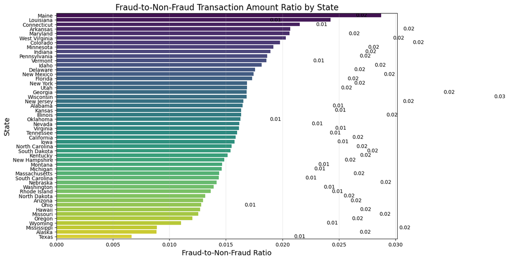

```python
# Calculate the total transaction amount for fraud and non-fraud grouped by state
state_totals = data_cleaned.groupby(['State', 'isFraud'])['amount'].sum().unstack(fill_value=0).reset_index()

# Add a new column for the fraud-to-non-fraud ratio
state_totals['fraud_ratio'] = state_totals[1] / (state_totals[0] + 1e-6)  # Add small value to avoid division by zero

# Sort by fraud ratio in descending order
state_totals = state_totals.sort_values(by='fraud_ratio', ascending=False)

# Create the bar plot
plt.figure(figsize=(12, 8))
sns.barplot(
    y='State',
    x='fraud_ratio',
    data=state_totals,
    palette='viridis'
)

# Annotate the bars with the fraud ratios
for index, row in state_totals.iterrows():
    plt.text(
        row['fraud_ratio'] + 0.01, index,
        f"{row['fraud_ratio']:.2f}",
        va='center', ha='left', fontsize=10
    )

# Add labels and title
plt.title("Fraud-to-Non-Fraud Transaction Amount Ratio by State", fontsize=16)
plt.xlabel("Fraud-to-Non-Fraud Ratio", fontsize=14)
plt.ylabel("State", fontsize=14)
plt.grid(axis='x', alpha=0.3)
plt.show()
```

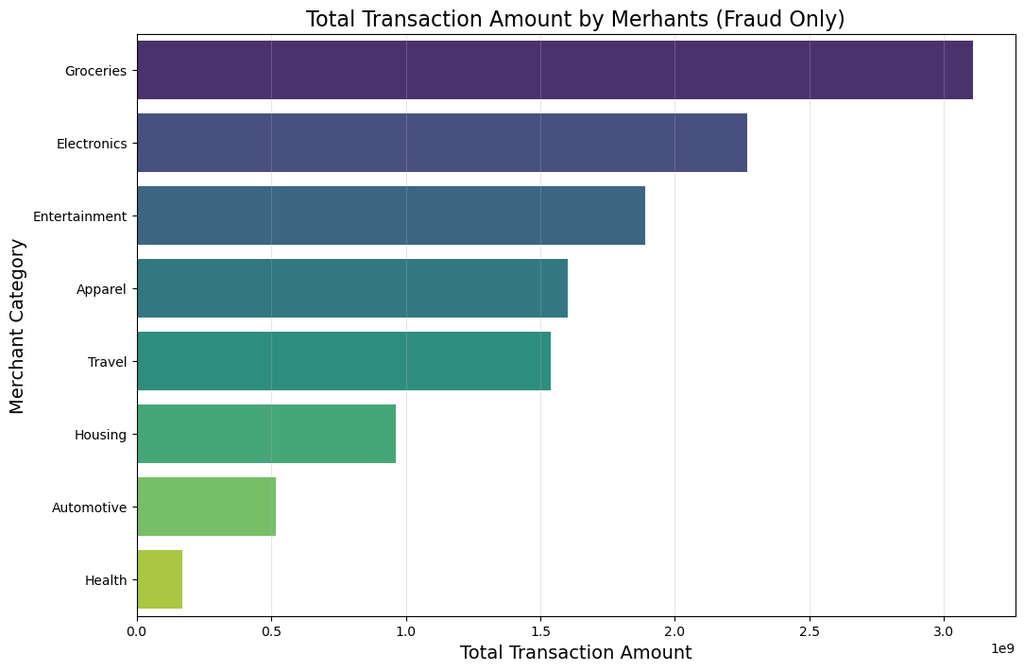

```python
# Group the data for fraud transactions by city and calculate the total transaction amount
fraud_city_totals = data_cleaned[data_cleaned['isFraud'] == 1].groupby('merchant_category')['amount'].sum().reset_index()

# Sort by total transaction amount in descending order
fraud_city_totals = fraud_city_totals.sort_values(by='amount', ascending=False)

# Create the bar plot
plt.figure(figsize=(12, 8))
sns.barplot(
    y='merchant_category',
    x='amount',
    data=fraud_city_totals,
    palette='viridis'
)

# Add labels and title
plt.title("Total Transaction Amount by Merhants (Fraud Only)", fontsize=16)
plt.xlabel("Total Transaction Amount", fontsize=14)
plt.ylabel("Merchant Category", fontsize=14)
plt.grid(axis='x', alpha=0.3)
plt.show()
```

### **Insights from the Graph**

- **Dominant Merchant Categories**:
  - **Groceries** is the leading category for fraudulent transactions in terms of total transaction amount. This may indicate a high volume of fraudulent transactions in everyday shopping.
  - **Electronics** follows closely, suggesting that fraudsters target high-value items in this category.
- **Moderate Fraud Categories**:
  - Categories such as **Entertainment**, **Apparel**, and **Travel** show significant fraudulent activity, indicating fraud in luxury or discretionary spending.
- **Low Fraud Categories**:
  - **Automotive** and **Health** categories have the lowest total fraudulent transaction amounts, indicating less frequent targeting by fraudsters.

### **Why This Insight Is Important**

- **Risk Identification**:
  - The graph highlights which merchant categories are most vulnerable to fraud. High-risk categories like **Groceries** and **Electronics** may require stricter monitoring.
- **Fraud Prevention Strategies**:
  - Tailored fraud detection measures can be applied to high-risk merchant categories to minimize financial losses.
- **Understanding Fraud Patterns**:
  - This categorization can help businesses identify trends and align their fraud detection systems to target specific sectors effectively.

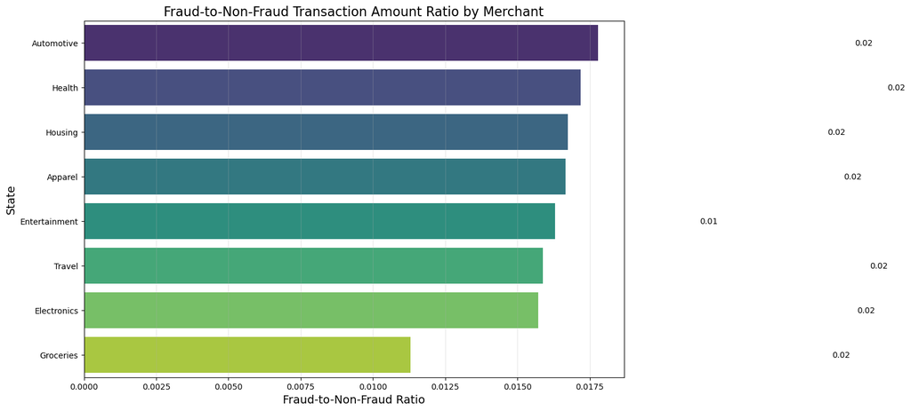

```python
# Calculate the total transaction amount for fraud and non-fraud grouped by state
state_totals = data_cleaned.groupby(['merchant_category', 'isFraud'])['amount'].sum().unstack(fill_value=0).reset_index()

# Add a new column for the fraud-to-non-fraud ratio
state_totals['fraud_ratio'] = state_totals[1] / (state_totals[0] + 1e-6)  # Add small value to avoid division by zero

# Sort by fraud ratio in descending order
state_totals = state_totals.sort_values(by='fraud_ratio', ascending=False)

# Create the bar plot
plt.figure(figsize=(12, 8))
sns.barplot(
    y='merchant_category',
    x='fraud_ratio',
    data=state_totals,
    palette='viridis'
)

# Annotate the bars with the fraud ratios
for index, row in state_totals.iterrows():
    plt.text(
        row['fraud_ratio'] + 0.01, index,
        f"{row['fraud_ratio']:.2f}",
        va='center', ha='left', fontsize=10
    )

# Add labels and title
plt.title("Fraud-to-Non-Fraud Transaction Amount Ratio by Merchant", fontsize=16)
plt.xlabel("Fraud-to-Non-Fraud Ratio", fontsize=14)
plt.ylabel("State", fontsize=14)
plt.grid(axis='x', alpha=0.3)
plt.show()
```

### **Insights from the Graph**

- **High Fraud-to-Non-Fraud Ratio Categories**:
  - **Automotive** and **Health** categories have the highest fraud-to-non-fraud transaction ratios.
  - These categories are particularly vulnerable despite potentially lower overall transaction volumes.
- **Moderate Fraud-to-Non-Fraud Ratio Categories**:
  - Categories like **Housing**, **Apparel**, and **Entertainment** show moderate ratios, suggesting fraud is present but not disproportionately higher compared to non-fraud transactions.
- **Low Fraud-to-Non-Fraud Ratio Categories**:
  - **Groceries** and **Electronics** have relatively lower ratios, indicating a significant number of non-fraud transactions that balance out the fraud transactions.
- **Risk Prioritization**:
  - Merchant categories like **Automotive** and **Health** require focused fraud prevention efforts due to their disproportionately higher fraud ratios.
- **Fraud Patterns**:
  - The graph highlights patterns that help identify categories where fraud occurs at a higher frequency relative to legitimate transactions.
- **Tailored Fraud Detection**:
  - Businesses can allocate resources to enhance fraud detection and monitoring systems for high-risk categories while maintaining adequate oversight in moderate-risk ones.
- **Strategic Decision-Making**:
  - Understanding these ratios helps businesses and financial institutions design more effective fraud prevention strategies tailored to specific merchant categories.

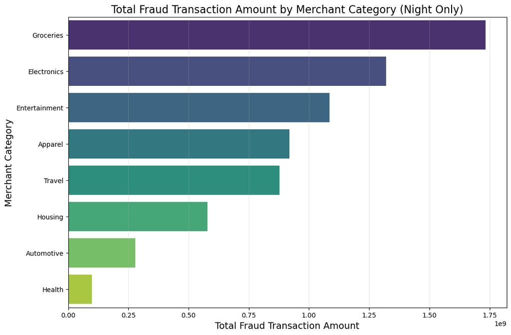

```python
# Filter data for fraud transactions at night
fraud_night_data = data_cleaned[(data_cleaned['isFraud'] == 1) & (data_cleaned['time_of_day'] == 'Night')]

# Group by 'merchant_category' and calculate total transaction amount
fraud_night_totals = fraud_night_data.groupby('merchant_category')['amount'].sum().reset_index()

# Sort by total transaction amount in descending order
fraud_night_totals = fraud_night_totals.sort_values(by='amount', ascending=False)

# Create the bar plot
plt.figure(figsize=(12, 8))
sns.barplot(
    y='merchant_category',
    x='amount',
    data=fraud_night_totals,
    palette='viridis'
)

# Add labels and title
plt.title("Total Fraud Transaction Amount by Merchant Category (Night Only)", fontsize=16)
plt.xlabel("Total Fraud Transaction Amount", fontsize=14)
plt.ylabel("Merchant Category", fontsize=14)
plt.grid(axis='x', alpha=0.3)
plt.show()
```

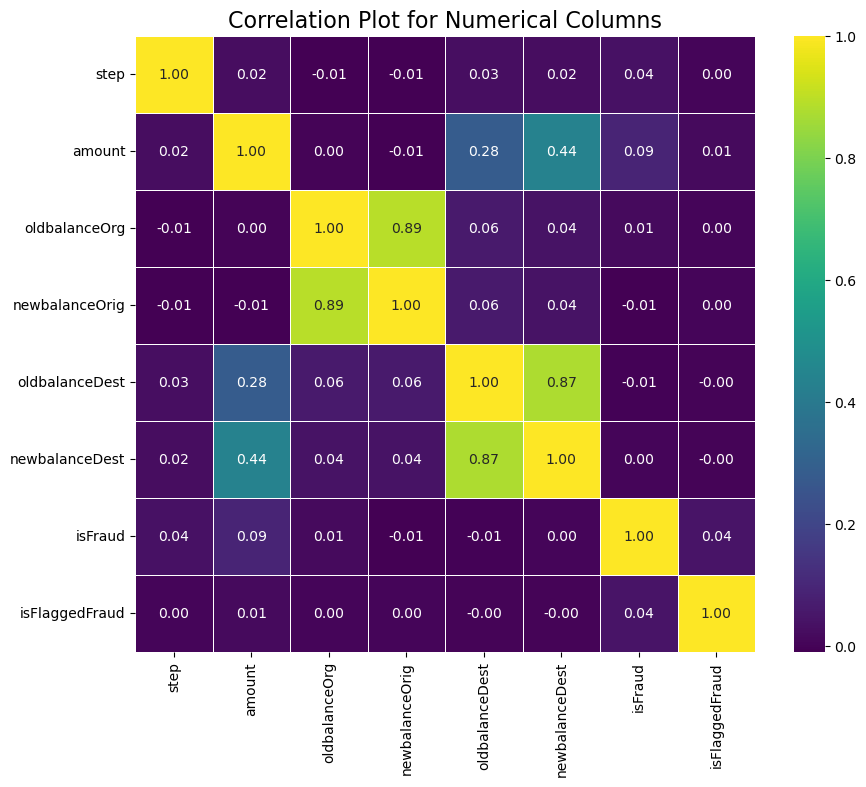

```python
plt.figure(figsize=(10, 8))  #Set figure size for the correlation plot
numerical_columns = data_cleaned.select_dtypes(include=['float64', 'int64']).columns  #Select only numerical columns
correlation_matrix = data_cleaned[numerical_columns].corr()  #Calculate the correlation matrix for numerical columns
sns.heatmap(
    correlation_matrix,
    annot=True,
    cmap='viridis',
    fmt='.2f',
    linewidths=0.5
)  #Create the heatmap with annotations

plt.title("Correlation Plot for Numerical Columns", fontsize=16)  #Add title
plt.show()
```

- **`isFraud`** has weak correlations with most features, indicating that fraudulent behavior might not directly depend on individual numerical variables. Instead, it could rely on a combination of features or categorical data.
- **No Strong Relationships with `isFlaggedFraud`**:
  - The column **`isFlaggedFraud`** shows negligible correlations with other features, suggesting that flagged transactions are not strongly influenced by any individual numerical feature.
- **Feature Engineering**:
  - High correlation between **`oldbalanceOrg`** and **`newbalanceOrig`**, as well as **`oldbalanceDest`** and **`newbalanceDest`**, could lead to redundancy. It might be beneficial to remove one of these pairs to avoid multicollinearity in machine learning models.
- **Fraud Detection Challenges**:
  - The weak correlations between `isFraud` and numerical features indicate that fraudulent transactions might not be easily separable using basic numerical patterns. Advanced methods or additional features may be required to detect fraud effectively.
- **Focus on Combined Insights**:
  - Since individual correlations with `isFraud` are weak, combining multiple features (e.g., balances and transaction amounts) or adding categorical/contextual data might enhance the model's performance.

```python
# Separate features and target variable
X = data_cleaned.drop(columns=['isFraud'])
y = data_cleaned['isFraud']

# Define categorical and numerical columns
categorical_columns = ['type', 'State', 'merchant_category', 'time_of_day']
numerical_columns = ['step', 'amount', 'oldbalanceOrg', 'newbalanceOrig', 'oldbalanceDest', 'newbalanceDest', 'isFlaggedFraud']

# Use OneHotEncoder for categorical features
preprocessor = ColumnTransformer(
    transformers=[
        ('num', 'passthrough', numerical_columns),
        ('cat', OneHotEncoder(handle_unknown='ignore'), categorical_columns)
    ]
)

# Transform the features
X_transformed = preprocessor.fit_transform(X)

# Apply SMOTE
smote = SMOTE(random_state=42)
X_resampled, y_resampled = smote.fit_resample(X_transformed, y)

# Verify the new class distribution
print("\nClass distribution after SMOTE:")
print(pd.Series(y_resampled).value_counts(normalize=True))

# Combine resampled features and target variable into a DataFrame
# Convert OneHotEncoder's sparse matrix to dense DataFrame
X_resampled_df = pd.DataFrame.sparse.from_spmatrix(X_resampled, columns=preprocessor.get_feature_names_out())
X_resampled_df['isFraud'] = y_resampled
```

```
Class distribution after SMOTE:
isFraud
0    0.5
1    0.5
Name: proportion, dtype: float64
```